# Homework Tidyverse

Hamid Semiyari

Author

Zak Zerhouni

Published

September 27, 2026

```r
if(!require("pacman")) install.packages("pacman")
pacman::p_load(tidyverse, gapminder, broom)
```

# Problem 1:

Copy paste and run the tribble given below.

```r
tribble( ~x,    ~y,    ~w,    ~z,
              210,   300,   220,   180,
              102,   100,   119,   187,
              176,   175,   188,   173,
              87,    95,   91,     94,
              202,   210,  234,    218,
              110,   122,  131,    128,
) -> dt
# Copied and pasted the tribble to run it.
tribble( ~x,    ~y,    ~w,    ~z,
              210,   300,   220,   180,
              102,   100,   119,   187,
              176,   175,   188,   173,
              87,    95,   91,     94,
              202,   210,  234,    218,
              110,   122,  131,    128,
)
```

```
# A tibble: 6 × 4
      x     y     w     z
  <dbl> <dbl> <dbl> <dbl>
1   210   300   220   180
2   102   100   119   187
3   176   175   188   173
4    87    95    91    94
5   202   210   234   218
6   110   122   131   128
```

## 1_a:

- Use and show a `map` function to find the “mean” of each column of the `dt` data table

```r
# The map function is used to generate a list of the mean of each column
dt |>
  set_names(c("x.Mean", "y.Mean", "w.Mean", "z.Mean")) |>
  map(mean) |> data.frame()
```

```
    x.Mean y.Mean   w.Mean   z.Mean
1 147.8333    167 163.8333 163.3333
```

## 1_b:

- Use and show a `map` function to find the “standard deviation” of each column of the `dt` data table.

```r
# The function we map is changed to sd for the standard deviation
dt |> set_names(c("x.SD", "y.SD", "w.SD", "z.SD")) |> map(sd) |> data.frame()
```

```
      x.SD     y.SD     w.SD     z.SD
1 54.45151 79.12016 58.40348 44.66617
```

## 1_c:

- Use and show a map function that will calculate the “square root” of each value of each column of the data table `dt`.

```r
# The function mapped is changed to sqrt
dt |> set_names(c("x.sqrt", "y.sqrt", "w.sqrt", "z.sqrt")) |> map(sqrt) |> data.frame()
```

```
     x.sqrt    y.sqrt    w.sqrt   z.sqrt
1 14.491377 17.320508 14.832397 13.41641
2 10.099505 10.000000 10.908712 13.67479
3 13.266499 13.228757 13.711309 13.15295
4  9.327379  9.746794  9.539392  9.69536
5 14.212670 14.491377 15.297059 14.76482
6 10.488088 11.045361 11.445523 11.31371
```

## 1_d:

- Use R code to find the “mean”, “max”, “1st Quartile”, “3rd Quartile”, “Median”, and “Min” for each column of the `dt` data table. (Hint: You do not have to use a map function)

```r
# The summary function is used to display the min, 1st quartile, median,
# mean, 3rd quartile, and the max.
dt |> summary()
```

```
       x               y               w               z
 Min.   : 87.0   Min.   : 95.0   Min.   : 91.0   Min.   : 94.0
 1st Qu.:104.0   1st Qu.:105.5   1st Qu.:122.0   1st Qu.:139.2
 Median :143.0   Median :148.5   Median :159.5   Median :176.5
 Mean   :147.8   Mean   :167.0   Mean   :163.8   Mean   :163.3
 3rd Qu.:195.5   3rd Qu.:201.2   3rd Qu.:212.0   3rd Qu.:185.2
 Max.   :210.0   Max.   :300.0   Max.   :234.0   Max.   :218.0
```

# Problem 2:

Write a function that uses a for loop that, for each iteration, randomly draws 5 observations from an exponential distribution with “rate” parameter 1 (use `rexp()`) and calculates its “mean”. It should do this 10,000 times. Choose an appropriate plot to plot the distribution of “means”.

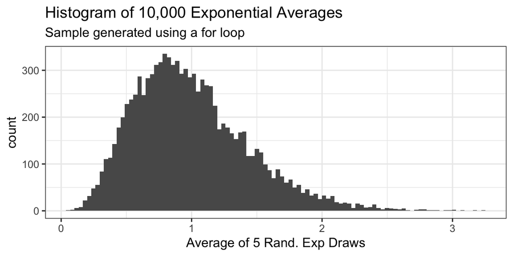

```r
# Set a seed for reproducibility
set.seed(4670329)

# Write the function to average out 5 random exponential draws and then
# append each average to a vector that is returned.
exponential_draw <- function(n) {
  # Initialize an empty vector
  vector_of_averages <- c()
  for(i in 1:n) {
    # compute the mean of the 5 ran. exp draws with rate=1
    mu <- mean(rexp(5,1))
    # The rbind function is used to append the most recent mean in the loop.
    vector_of_averages<- rbind(vector_of_averages,mu,deparse.level = 0)
  }
  return(vector_of_averages)
}

# Save a vector of 10,000 averages.
ten_thousand_draws <- exponential_draw(10000)

# Plot the vector as a histogram to get a view of the shape of the
# distribution.
ggplot(data = data.frame(ten_thousand_draws), aes(x = ten_thousand_draws))+geom_histogram(bins = 100)+labs(title = "Histogram of 10,000 Exponential Averages", x = "Average of 5 Rand. Exp Draws", subtitle = "Sample generated using a for loop")
```

## 2_a:

- Repeat part 1 by using a `map_*()` function.

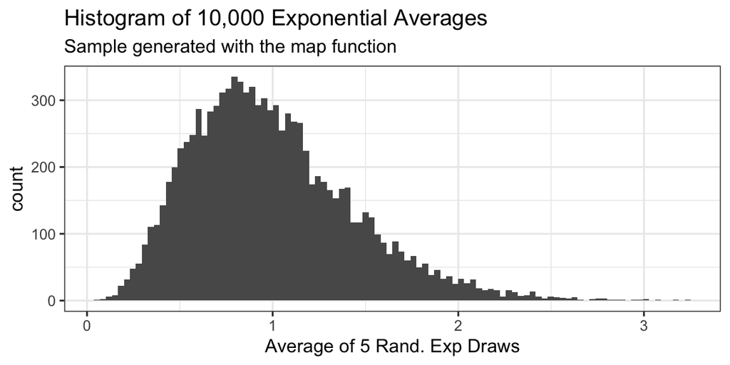

```r
# The same seed is used.
set.seed(4670329)
# A vector of 10000 is created and then mapped with map_dbl. This produces
# a sample of averages of 5 random exponential values generated.
ten_thousand_draws.map <- vector(mode="numeric", length = 10000) |>
  map_dbl(\(x) mean(rexp(5,1)))
# An anonymous function is used inside of map_dbl to reassign the
# value in the original vector.

#Plot the vector as a histogram to get a view of the shape of the
# distribution.
ggplot(data = data.frame(ten_thousand_draws.map), aes(x = ten_thousand_draws))+geom_histogram(bins = 100)+labs(title = "Histogram of 10,000 Exponential Averages", x = "Average of 5 Rand. Exp Draws",subtitle="Sample generated with the map function")
```

## 2_b:

- Repeat part 1 by using the `replicate()` function.

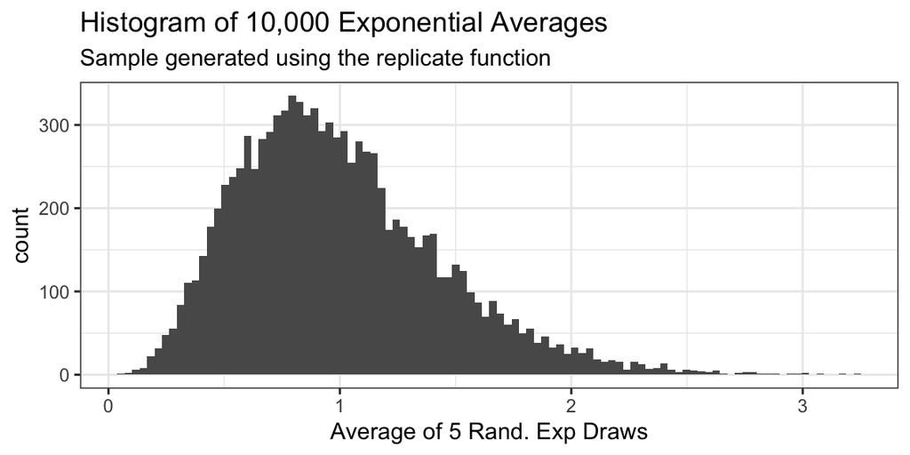

```r
set.seed(4670329)
# Replicate is compact enough to fit directly into the ggplot object.
ggplot(data = data.frame(draws = replicate(10000,mean(rexp(5,1)))),
       aes(x = draws)
       )+
  geom_histogram(bins=100)+
  labs(title = "Histogram of 10,000 Exponential Averages", x = "Average of 5 Rand. Exp Draws",subtitle = "Sample generated using the replicate function")
```

## 2_c:

- Use a another for loop that will print out plots for sample sizes of 5, 10, and 20 observations (instead of just 5).

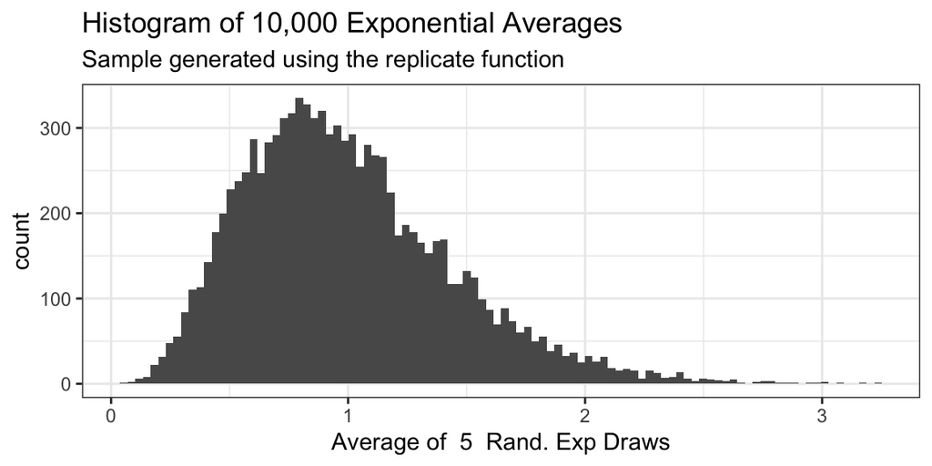

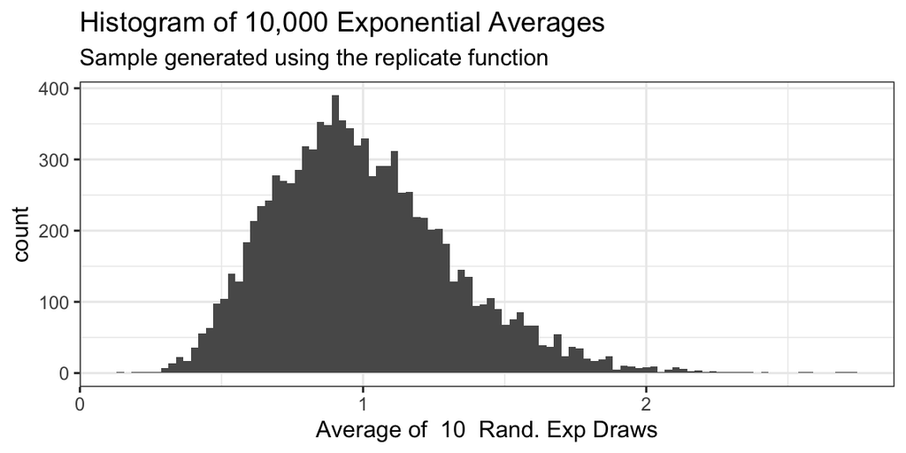

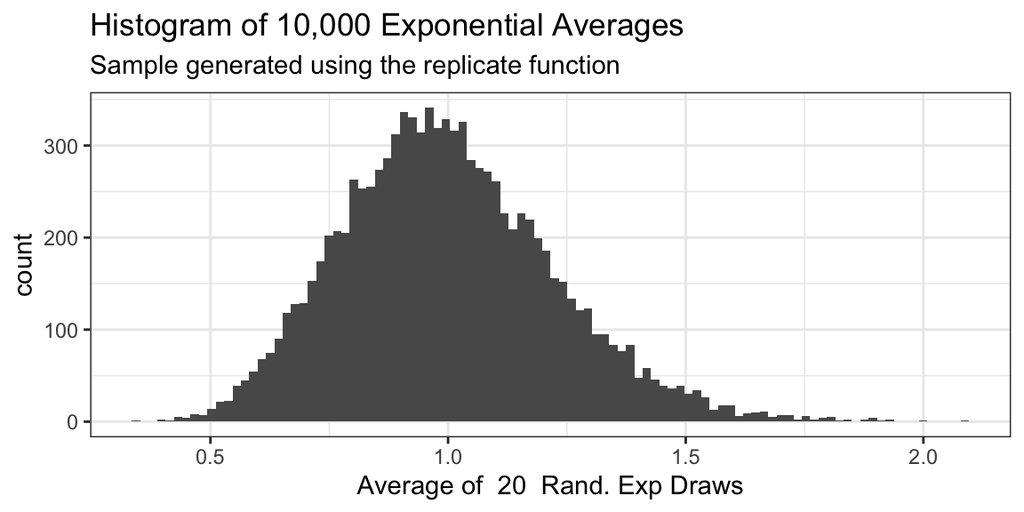

```r
set.seed(4670329)
# Iterate through a list of the desired sample sizes in the for loop
for(i in c(5,10,20)) {
  # Using the replicate method, we generate our 10000 sample by
  # generating i random exponential draws and taking the mean
  p <- ggplot(data = data.frame(draws = replicate(10000,mean(rexp(i,1)))),
       aes(x = draws)
       )+
  geom_histogram(bins=100)+
  labs(title = "Histogram of 10,000 Exponential Averages", x = paste( "Average of ", i, " Rand. Exp Draws" ),subtitle = "Sample generated using the replicate function")
  # The paste function is used to change the number of draws in the x label.
  # Each graphic has to be printed to render from within the for loop.
  print(p)
}
```

# Problem 3:

- Use and show R coding to calculate the “standard deviation” for each variable of the data table `mtcars` using the “Special For Loop Method”.

The “Special For Loop Method”

```r
# Create a function to use the "Special For Loop Method"
dataframe_sd <- function(df) {
  # Create a vector as long as the number of features in our data set
  for_loop_output <- vector("numeric", ncol(df))
  # Iterate the four loop across the numeric indices of the data set
  for (i in seq_along(df)) {
    # Replace the value in the vector with the output of sd
    for_loop_output[[i]] <- sd(df[[i]])
  }
  # Return the output of the values of the sd function as a vector,
  # while renaming the columns with the suffix .sd
  final_output <- for_loop_output |>
         set_names(colnames(df) |>
             map_chr(paste, ".",
                     as.character(quote(sd)), collapse="") |>
               map_chr(str_replace_all, " ", ""))
  return(final_output)
}

dataframe_sd(mtcars)
```

```
     mpg.sd      cyl.sd     disp.sd       hp.sd     drat.sd       wt.sd
  6.0269481   1.7859216 123.9386938  68.5628685   0.5346787   0.9784574
    qsec.sd       vs.sd       am.sd     gear.sd     carb.sd
  1.7869432   0.5040161   0.4989909   0.7378041   1.6152000
```

# Problem 4:

Generate a sequence of dates from **January 1, 2015** to **December 31, 2025**, spaced by every **two months**. Extract the **year**, **quarter**, and **ISO week number** for each date.

```r
# The dates are generated as a sequence from two dates.
# With the by option we can generated a sequence every two months.
dates_2015_to_2025 <- seq(ymd("2015-01-01"), ymd("2025-12-31"), by="2 month")

# Using year, quarter, month, and isoweek, we can extract the components of the
# dates.
# We can then combine them into a data frame to store them in a tidy manner.
dates.data <- data.frame(year(dates_2015_to_2025), quarter(dates_2015_to_2025),
  month(dates_2015_to_2025),
  isoweek(dates_2015_to_2025)) |> set_names(c("Year", "Quarter", "Month", "ISO Week"))
head(dates.data)
```

```
  Year Quarter Month ISO Week
1 2015       1     1        1
2 2015       1     3        9
3 2015       2     5       18
4 2015       3     7       27
5 2015       3     9       36
6 2015       4    11       44
```

# Problem 5

Given the following dates, compute the difference in **months** and **weeks** between each consecutive pair.

```r
# Convert the strings into Date objects.
sample_dates <- ymd(c("2018-03-15", "2020-07-20", "2023-01-10", "2025-09-05"))

# Create a function to compute the months and weeks between consecutive dates.
compute_differences <- function(sample_dates) {
  # Initialize vector for months.
  months_difference <- c()
  # Initialize vector for weeks.
  weeks_difference <- c()
  for(i in 2:length(sample_dates)) {
    # Convert to an Interval object.
    difference_interval <- interval(sample_dates[i-1],sample_dates[i])
    # Divide the Interval object by a one month or one week period object respectively.
    difference_in_months <- difference_interval/months(1)
    difference_in_weeks <- difference_interval/weeks(1)
    # Append the calculated difference value to the respective vector.
    months_difference <- rbind(months_difference,difference_in_months, deparse.level = 0)
    weeks_difference <- rbind(weeks_difference,difference_in_weeks, deparse.level = 0)
  }
  # Store the computed vectors in a data frame.
  difference_dataframe <- data.frame(months = months_difference,
                                     weeks = weeks_difference)
  # Return the completed difference computations as a data frame.
  return(difference_dataframe)
}

compute_differences(sample_dates)
```

```
    months    weeks
1 28.16129 122.5714
2 29.67742 129.1429
3 31.83871 138.4286
```

# Problem 6

Given a list of mixed date formats, use `map()` and `possibly()` from `purrr` to safely convert them to **Date** format and extract the **month name**.

```r
date_strings <- list("2023-06-10", "2022/12/25", "15-Aug-2021", "InvalidDate")
# Create a purrr:possibly function in order to pass parameters through map_vec.
parse_dt_possibly <- purrr::possibly(parse_date_time, NA)
# Use map_vec to use the possibly function to handle errors.
# Enter the 'ymd' and 'dmy' formats seen in the list as parameters for parse_date_time.
parsed_dates <- date_strings |>
  map_vec(parse_dt_possibly, orders = c('ymd','dmy'),quiet=TRUE) |> as.Date() |> month(label = TRUE)
# Use as.Date() to conver the POSIXct ojects into Date objects.
# Change the label setting in the month function to TRUE to display the month names.

parsed_dates
```

```
[1] Jun  Dec  Aug  <NA>
12 Levels: Jan < Feb < Mar < Apr < May < Jun < Jul < Aug < Sep < ... < Dec
```